# BBVA Éxito - Muestreo para Encuesta

Magdalena Bennett

William Fuchs

Jaime Millán

Marzo 17, 2022

# Diseño de muestreo

El objetivo es obtener una muestra clientes para cada país que nos permita dos cosas:

1. Validar la definición de éxito
2. Estudiar algunos factores que puedan estar explicando el éxito y que sean la base para futuras intervenciones.

Dado lo anterior, y con base en la información disponible proponemos el siguiente método para seleccionar la muestra de clientes a encuestar:

**Estratificación**: Dividiremos el universo de cada país utilizando variables que explican diferencias en los clientes y el éxito de sus empresas. La información se toma del primer crédito que cada cliente tuvo con el banco respectivo. Las variables para estratificar son:

1. *Tamaño del primer crédito (proxy de tamaño del negocio)*: Clientes grandes (sobre la mediana) y pequenõs (bajo la mediana)
2. *Sector Agrícola*: Negocios del sector agrícola y negocios de otro sector
3. *Nivel de vulnerabilidad*: Generaremos una variable con tres niveles dependiendo de la situación socioeconómica del cliente (vulnerabilidad, pobreza/pobreza extrema, y otro/sin información)/

Adicionalmente, incorporaremos variación regional dependiendo de la distribución geográfica de los clientes en los distintos estratos.

**Medida de éxito**: A continuación, dentro de cada estrato se creará una variable continua de “éxito”. Los insumos de esta son:

1. *Crecimiento del monto del crédito*
2. *Crecimiento de los excedentes del negocio* (primer vs último crédito)
3. *Días promedio de mora*

Estandarizaremos estas tres variables para una proxy continua de “éxito” donde en una esquina estarán los clientes con malos pagos, poco crecimiento (o decrecimiento) del negocio, y en el otro extremo aquellos clientes con muy buen comportamiento de pago y que además han crecido con respecto de manera significativa desde su primer crédito.

Utilizando dicha distribución, dentro de cada celda tomaremos una muestra uniforme con respecto a esta variable. Además, tomaremos una muestra adicional de individuos dentro del decil más alto con el fin de dar más peso a aquellos que consideramos exitosos. De esta forma obtendremos una muestra representativa de los diferentes tipos de empresas de cada país que nos permita hacer comparaciones a lo largo del espectro de distintos comportamientos asociados a éxito.

Existe un grupo que no entra dentro de este muestreo que son aquellos clientes con un solo crédito. En este caso, para aquellos clientes con buen pago pero solo un crédito seleccionaremos una sub-muestra teniendo en cuenta las restricciones de contacto de cada país. El tamaño de este grupo lo podemos definir con cada país.

Finalmente, potencialmente podemos incluir una selección en campo (por oficina o región) de aquellos casos que identifiquen los asesores como casos exitosos sobresalientes. Por ejemplo, aquellos que se tienen en cuenta para las memorias de cada institución a fin de año.

# Data Disponible

Para el siguiente análisis, contamos con 1932908 contratos históricos (excluyendo productos de Banca Comunal) entre el 2018 y 2021 para 4 oficinas de la Fundación BBVA en Latinoamérica, divididas de la siguiente manera:

Observaciones por oficina 2018-2021

| Pais | Oficina | N Clientes | N Contratos |
| --- | --- | --- | --- |
| Colombia | BA | 433895 | 796888 |
| Panamá | MS | 21971 | 31381 |
| Perú | FC | 318816 | 682973 |
| República Dominicana | AD | 243194 | 421666 |

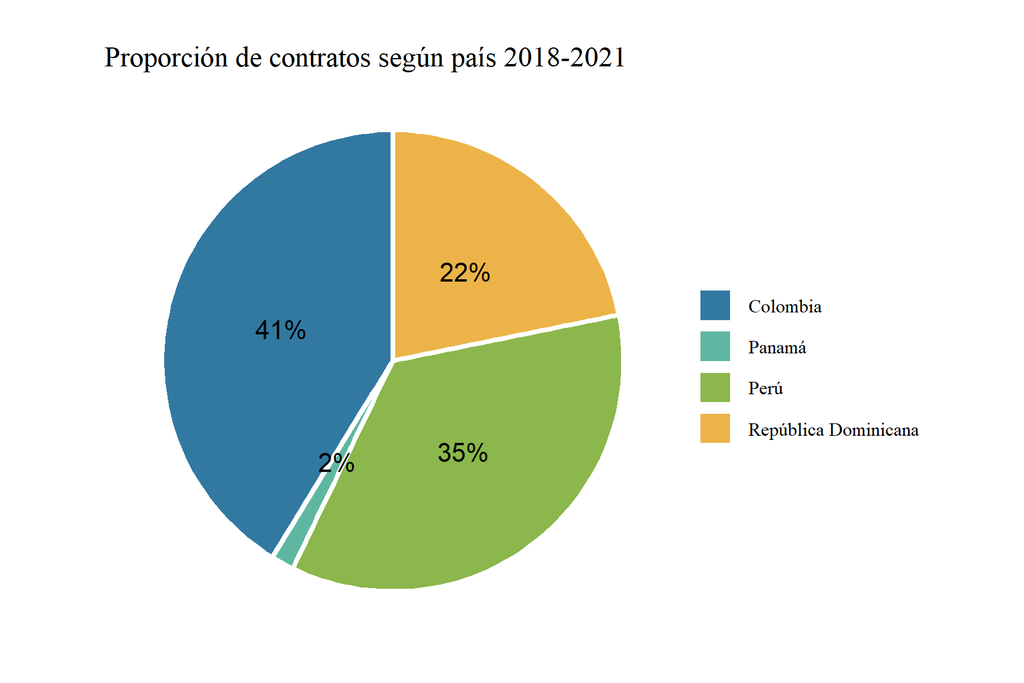

Como fue mencionado anteriormente, para la construcción de la muestra realizaremos un muestreo estratificado según tres variables claves:

- **Vulnerable vs No vulnerable**: Clientes clasificados como vulnerables vs no vulnerables (pobreza y extrema pobreza). Creamos una categoria adicional para los clientes que no tienen información o están categorizados como “Otro”.
- **Negocio grande vs pequeño**: Variable construida en base al crédito inicial (sobre y bajo la mediana)
- **Sector agrícola vs no agrícola**: Si el cliente está en el sector agrícola o no.

Dentro de dichos estratos, seleccionaremos una muestra basada en un **puntaje de éxito** construido en base al porcentaje de crecimiento del monto de crédito, excedentes del negocio, y dias de morosidad.

# Datos por País

## Colombia

Observando la distribución del monto del crédito incial, vemos una distribución continua con claros cortes de montos más frecuentes. En este caso, para dividir por montos iniciales más grandes o pequeños, separamos los negocios entre aquellos que están sobre y bajo la mediana (2231).

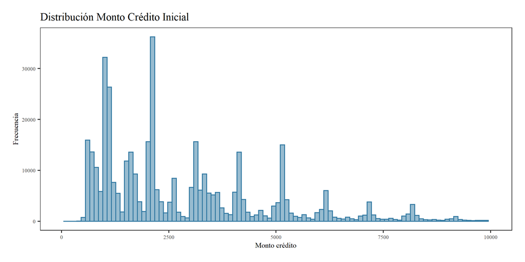

También estimamos un primer acercamiento a una medida de éxito que incorpora crecimiento porcentual en monto del crédito y excedentes del negocio (con un límite en 100%, para evitar outliers), además de incorporar días promedio de mora. En este caso, la medida de éxito se calcula de la siguiente manera:

$$Exito_i = \frac{1}{3}MoraPromedio SD_i + \frac{1}{3}\Delta MontoSD_i + \frac{1}{3}\Delta ExcedentesSD_i$$
Donde $MoraPromedioSD_i \sim N(0,1)$ representa la versión estandarizada de los días promedio de mora del cliente $i$, $\Delta MontoSD_i \sim N(0,1)$ es el crecimiento porcentual del monto del crédito entre el primer y último contrato, y finalmente $\Delta ExcedentesSD_i ~N(0,1)$ representa el crecimiento procentual del excedente del negocio entre el primer y último contrato.

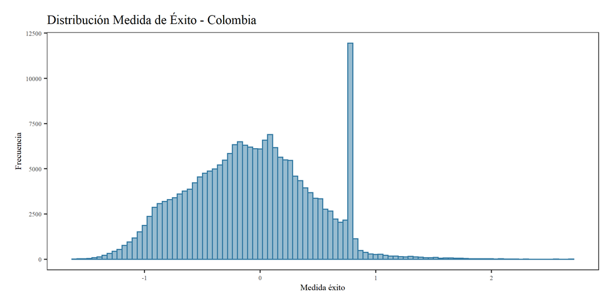

En cuanto a la distribución geográfica, observamos que la gran mayoría de los clientes se encuentra en las grandes ciudades, especialmente Bogotá y Medellín. En el siguiente mapa, se puede observar la distribución geográfica para todos los clientes, aquellos categorizados como exitosos, y también para los que pertenencen al decil superior del puntaje la medida continua de éxito anteriormente descrita:

[interactive chart not shown]

## Panamá

Para dividir por montos iniciales más grandes o pequeños, separamos los negocios entre aquellos que están sobre y bajo la mediana (1.14).

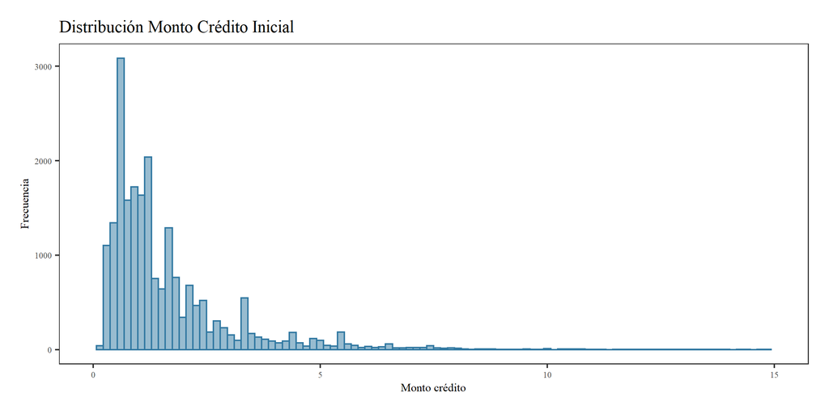

También estimamos la medida de éxito de la misma manera que fue descrito anteriormente.

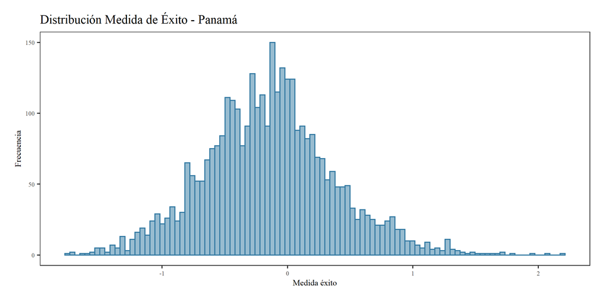

Finalmente, podemos ver la distribución de clientes según las oficinas asignadas. En este caso la distribución geográfica es bastante desagregada, incluso para los clientes más exitosos.

[interactive chart not shown]

## Perú

En el caso de Perú, realizamos un análisis similar a lo anterior, pero no incluimos datos de morosidad[^1]. Por lo tanto, la descripción de éxito solo se refiere a crecimiento de monto y de excedente.

Para dividir por montos iniciales más grandes o pequeños, separamos los negocios entre aquellos que están sobre y bajo la mediana (3).

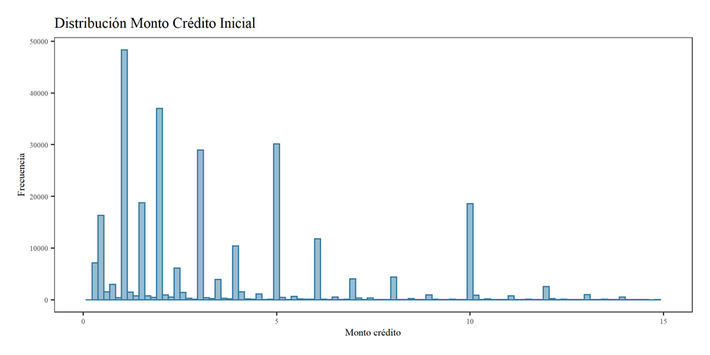

También estimamos la medida de éxito, en este caso solo utilizando crecimiento del monto y del excedente.

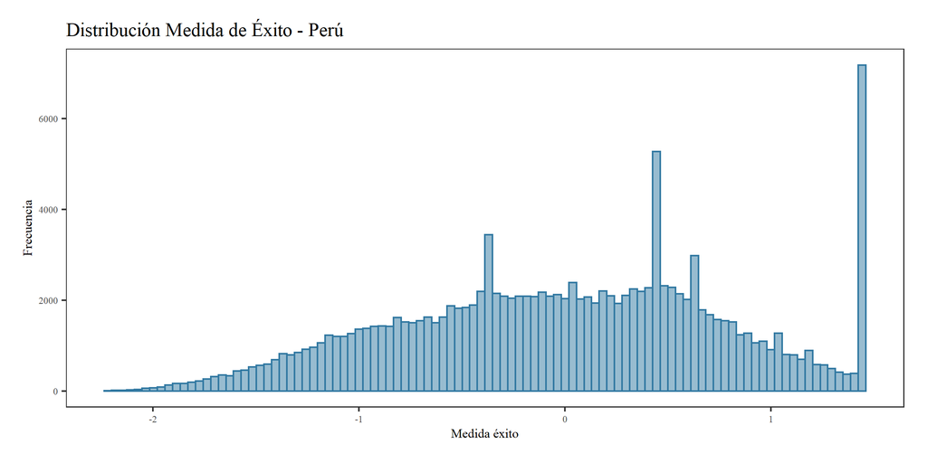

Finalmente, podemos ver la distribución de clientes según las oficinas asignadas. En este caso la distribución geográfica es bastante desagregada, incluso para los clientes más exitosos.

[interactive chart not shown]

## República Dominicana

Para dividir por montos iniciales más grandes o pequeños, separamos los negocios entre aquellos que están sobre y bajo la mediana (27).

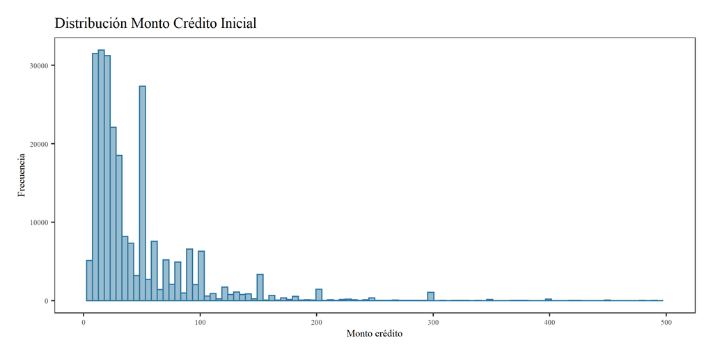

También estimamos la medida de éxito de la misma manera que fue descrito anteriormente.

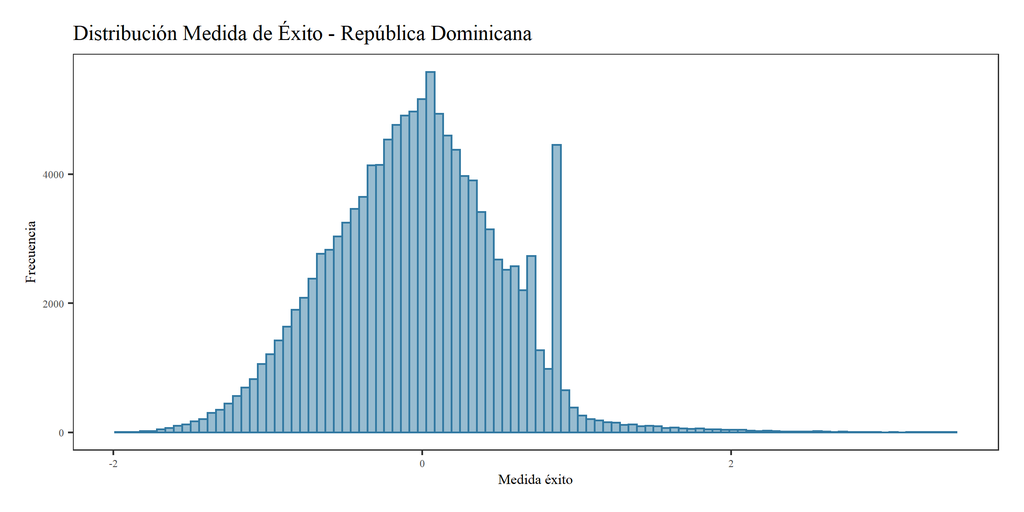

Finalmente, podemos ver la distribución de clientes según las oficinas asignadas. En este caso utilizamos las áreas mayores donde se encuentran dichas oficinas, por lo que puede haber más de una oficina en un área. Si bien hay una distribución bastante amplia de los clientes, la mayoría de los exitosos se encuentran en la zona de Santo Domingo.

[interactive chart not shown]

[^1]: Datos pendientes